# Deliverable 1

### Identify individuals considered as multivariant outliers

```r
library(chemometrics)
multivariant_outliers <- Moutlier(df[, c(11:12, 19, 26)], quantile = 0.995)
```

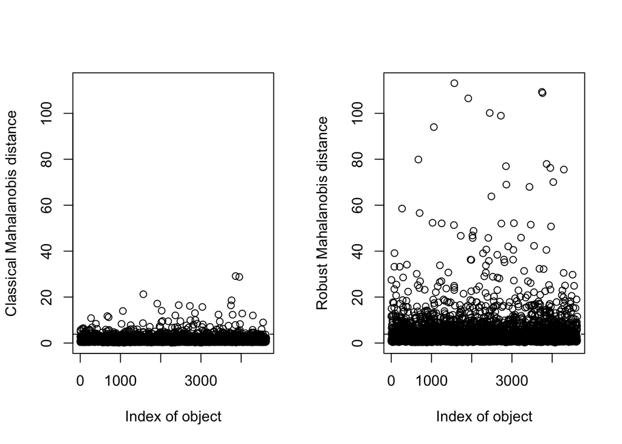

```r
multivariant_outliers$cutoff
```

```
## [1] 3.854901
```

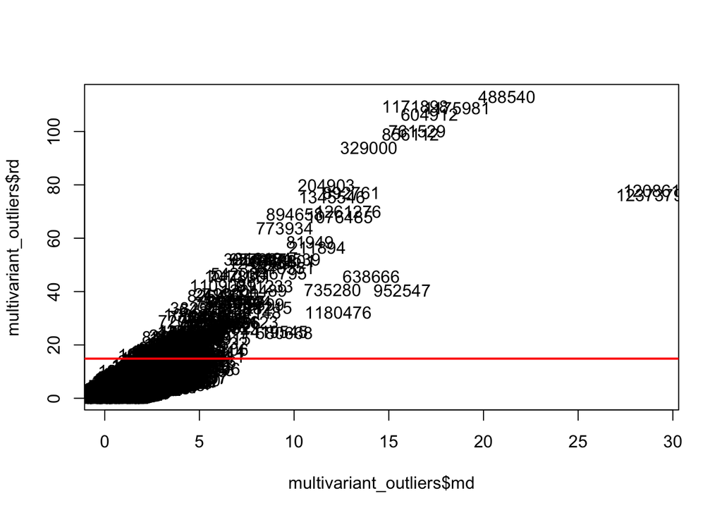

```r
par(mfrow=c(1,1))
plot(multivariant_outliers$md, multivariant_outliers$rd, type="n")
text(multivariant_outliers$md, multivariant_outliers$rd, labels=rownames(df[, c(11:12, 19, 26)]))
abline(col="red",lwd=2, h=qchisq(0.995, ncol(df[, c(11:12, 19, 26)])))
```

As we can see, above the defined line we have all the possible observations that we call multivariate outliers. These mean that, viewed only from the point of view of a variable, it does not have to be an outlier, but that viewed with various dimensions (variables), it may be so.

We want to look at two observations that have caught our attention. The first is 488540 and the second is 1180476.

As we can see, observation 488540 is the one at the boundary of the two axes. So that means it’s most likely a multivariate outlier. On the other hand, the 1180476 is not exactly very central on both axes. This may lead us to think that he is not as likely as the other observation to be a multivariate outlier.

```r
df[which(row.names(df)=="488540"), 1:35]
```

```
##                 VendorID lpep_pickup_datetime Lpep_dropoff_datetime
## 488540 f.Vendor-VeriFone  2016-01-11 06:57:31   2016-01-11 07:46:31
##        Store_and_fwd_flag RateCodeID Pickup_longitude Pickup_latitude
## 488540                  N     Rate-1        -73.91121              NA
##        Dropoff_longitude Dropoff_latitude Passenger_count Trip_distance
## 488540                NA               NA               1            30
##        Fare_amount Extra MTA_tax Tip_amount Tolls_amount Ehail_fee
## 488540          60     0     Yes         17            0        NA
##        improvement_surcharge Total_amount Payment_type   Trip_type hour
## 488540                   Yes       128.76  Credit card Street-Hail    6
##              period tlenkm traveltime espeed pickup dropoff Trip_distance_range
## 488540 Period night  48.28         49     55     06      07          Short_dist
##        yearGt2015 CashTips paidTolls Sum_total_amount TipIsGiven
## 488540          1        0        No               NA        Yes
##        passenger_groups
## 488540           Single
```

```r
df[which(row.names(df)=="1180476"), 1:35]
```

```
##                VendorID lpep_pickup_datetime Lpep_dropoff_datetime
## 1180476 f.Vendor-Mobile  2016-01-27 05:48:11   2016-01-27 06:19:48
##         Store_and_fwd_flag RateCodeID Pickup_longitude Pickup_latitude
## 1180476                  N Rate-Other        -73.90414        40.85212
##         Dropoff_longitude Dropoff_latitude Passenger_count Trip_distance
## 1180476          -73.9847         40.75537               1          10.5
##         Fare_amount Extra MTA_tax Tip_amount Tolls_amount Ehail_fee
## 1180476    33.76959     0      No          0            0        NA
##         improvement_surcharge Total_amount Payment_type Trip_type hour
## 1180476                    No            0         Cash  Dispatch    5
##               period   tlenkm traveltime   espeed pickup dropoff
## 1180476 Period night 16.89811   31.61667 32.06811     05      06
##         Trip_distance_range yearGt2015 CashTips paidTolls Sum_total_amount
## 1180476           Long_dist          0       NA        No               NA
##         TipIsGiven passenger_groups
## 1180476         No           Single
```